# Human Activity Recognition

Slydacious

September 24, 2015

### Synopsis

Using data from accelerometers on the belt, forearm, arm, and dumbell of six participants performing barbell lifts both correctly and incorrectly in five different ways, we estimate our prediction rate for out of sample data to be near 100% accurate. We achieve this by training a gradient boosted model using 10-fold cross-validation.

### Data Pre-processing

```r
# Set random seed for reproducibility
set.seed(138)

# Load caret library
library(caret)

# Load the data
trainData <- read.csv("pml-training.csv", row.names = 1)

# Show dimensions of the data
dim(trainData)
```

```
## [1] 19622   159
```

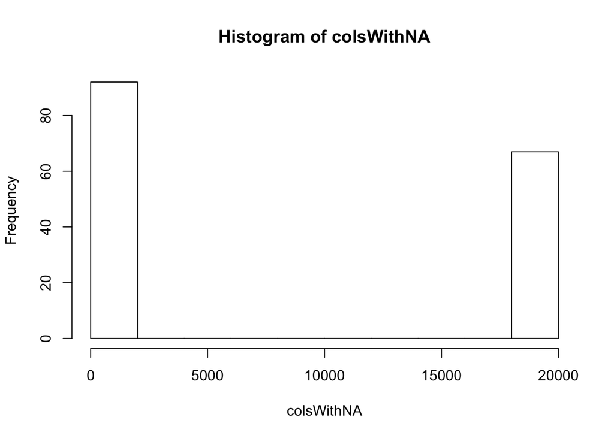

```r
# Show histogram of number of predictors(columns) with rows containing missing
# values
colsWithNA <- colSums(is.na(trainData))
hist(colsWithNA)
```

```r
unique(colsWithNA)
```

```
## [1]     0 19216
```

Since the number of rows with missing values in some predictors is very high, 19216, in relation to the total number of rows in our data, 19622, we will remove them instead of impute them.

```r
# Keep predictors where there are no missing values
trainData <- trainData[colsWithNA == 0]

# Remove predictors that have near zero variance
nzvCols <- nearZeroVar(trainData)
trainData <- trainData[ , -nzvCols]

# Partition training data into testing and validation sets using 60% of the
# data as training and the other 40% for validation
pTraining <- createDataPartition(trainData$classe, p = .60, list = F)
training <- trainData[pTraining,]
validation <- trainData[-pTraining,]
```

### Modeling and Training

Random forests and boosting are usually the two top performing algorithms in prediction contents. We will train a gradeint boosting model using ten-fold cross validation in order to meet our criteria for this project. Training with random forests was not used since that is usually more computationally intensive.

```r
# Use 10-fold cross validation
tControl <- trainControl(method = "cv", number = 10)

# Setup multi-core processing to speed up training
library(foreach)
library(doMC)
registerDoMC(cores = 8)

# Train with a gradient boosted model
modFit <- train(classe ~ ., data=training, method="gbm", trControl=tControl)
```

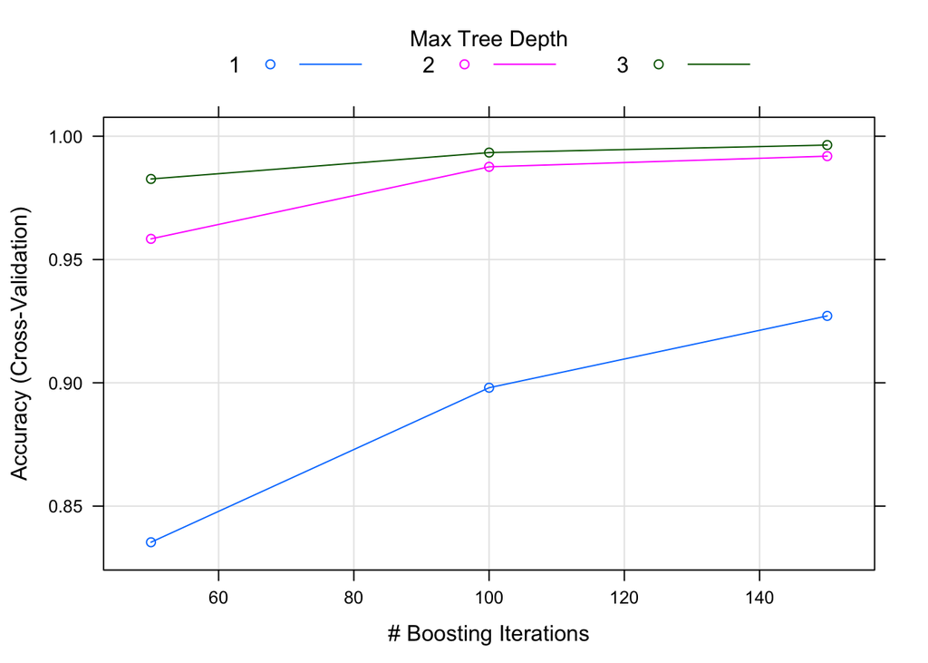

```r
plot(modFit)
```

### Results

```r
confMatrix <- confusionMatrix(predict(modFit, validation), validation$classe)
confMatrix$overall
```

```
##       Accuracy          Kappa  AccuracyLower  AccuracyUpper   AccuracyNull
##      0.9965588      0.9956470      0.9949971      0.9977310      0.2844762
## AccuracyPValue  McnemarPValue
##      0.0000000            NaN
```

The estimated out-of-sample accuracy of our gradient boosted model using ten-fold cross validation is 99.7% resulting in an out-of-sample error estimate of less than one percent.